# Reproducible Research: Peer Assessment 1

Test performed on a computer with:  
- Ubuntu operating system 16.04  
- Version 0.99.903 – © 2009-2016 RStudio  
- R version 3.3.3

Author:Marco Guado  
Barcelona, July 2017

# Introduction

It is now possible to collect a large amount of data about personal movement using activity monitoring devices such as a Fitbit, Nike Fuelband, or Jawbone Up. These type of devices are part of the “quantified self” movement – a group of enthusiasts who take measurements about themselves regularly to improve their health, to find patterns in their behavior, or because they are tech geeks. But these data remain under-utilized both because the raw data are hard to obtain and there is a lack of statistical methods and software for processing and interpreting the data.

This assignment makes use of data from a personal activity monitoring device. This device collects data at 5 minute intervals through out the day. The data consists of two months of data from an anonymous individual collected during the months of October and November, 2012 and include the number of steps taken in 5 minute intervals each day.

Data The data for this assignment can be downloaded from the course web site:

Dataset: Activity monitoring data [52K] The variables included in this dataset are:

steps: Number of steps taking in a 5-minute interval (missing values are coded as NA)

date: The date on which the measurement data was taken in YYYY-MM-DD format

interval: Identifier for the 5-minute interval in which measurement was taken

The dataset is stored in a comma-separated-value (CSV) file and there are a total of 17,568 observations in this dataset.

Assignment This assignment will be described in multiple parts. You will need to write a report that answers the questions detailed below. Ultimately, you will need to complete the entire assignment in a single R markdown document that can be processed by knitr and be transformed into an HTML file.

Throughout your report make sure you always include the code that you used to generate the output you present. When writing code chunks in the R markdown document, always use echo = TRUE so that someone else will be able to read the code. This assignment will be evaluated via peer assessment so it is essential that your peer evaluators be able to review the code for your analysis.

For the plotting aspects of this assignment, feel free to use any plotting system in R (i.e., base, lattice, ggplot2).

Fork/clone the GitHub repository created for this assignment. You will submit this assignment by pushing your completed files into your forked repository on GitHub. The assignment submission will consist of the URL to your GitHub repository and the SHA-1 commit ID for your repository state.

NOTE: The GitHub repository also contains the dataset for the assignment so you do not have to download the data separately.

# Loading and preprocessing the data

## 1. Code for reading in the dataset and/or processing the data

Download the zipped file and are located in the folder of work.

```r
#Load the data (i.e. read.csv())
if( !(file.exists("data/data_activity.zip") == TRUE) ){

  dir.create('data')
  download.file("http://d396qusza40orc.cloudfront.net/repdata/data/activity.zip", destfile="data/data_activity.zip")
  unzip('data/data_activity.zip', exdir='data')

}
```

Nota.- If you use https to download the file and you get a message: “unsopported URL scheme”, only use http as in the example above.

Read data from csv file and store it in a memory variable named ‘data’.  
Process/transform the data (if necessary) into a format suitable for your analysis  
We create a new data set excluding records that contain NA.

```r
data <- read.csv('data/activity.csv')
head(data)
nrow(data)

subdata = data[!is.na(data$steps), ]
head(subdata)
nrow(subdata)
```

[output not shown]

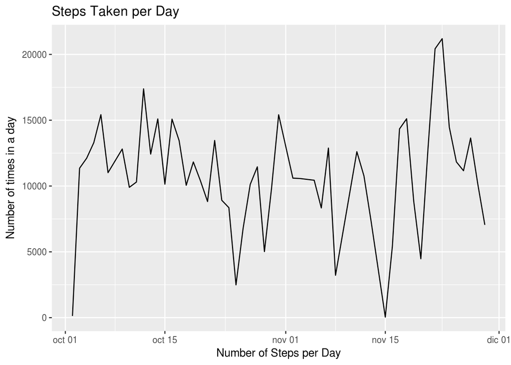

Steps Taken per Day

```r
#group for day
temp <- aggregate(subdata$steps, list(subdata$date), sum)
temp.date.character <- as.Date.character(temp$Group.1)
temp.date <- as.Date(temp.date.character, "%Y/%m/%d")

num.steps.date <- data.frame(temp.date, temp$x)
colnames(num.steps.date) <- c("date", "steps")
head(num.steps.date)

library(ggplot2)
#hist
ggplot(data=num.steps.date, aes(date,steps)) +
  geom_line() +
  ggtitle("Steps Taken per Day") +
  labs(x="Number of Steps per Day", y="Number of times in a day")
```

## 3. Mean and median number of steps taken each day

```r
#mean and median
steps_mean   <- mean(num.steps.date$steps)
steps_median <- median(num.steps.date$steps)
steps_mean
steps_median
```

[output not shown]

## 4. Time series plot of the average number of steps taken

[figure not shown]

Average number of steps taken

```r
#We only take those records other than 0 to get the mean
subdata.steps <- subdata[subdata$steps != 0,]
head(subdata.steps)
temp <- aggregate(subdata.steps$steps, list(subdata.steps$date), mean )
temp.date.character <- as.Date.character(temp$Group.1)
temp.date <- as.Date(temp.date.character, "%Y/%m/%d")

num.steps.date <- data.frame(temp.date, temp$x)
colnames(num.steps.date) <- c("date", "steps")
head(num.steps.date)

ggplot(data=num.steps.date, aes(date,steps)) +
  geom_line() +
  ggtitle("Average number of steps taken") +
  labs(x="Steps per Day", y="Average steps in a day")
```

## 5. The 5-minute interval that, on average, contains the maximum number of steps

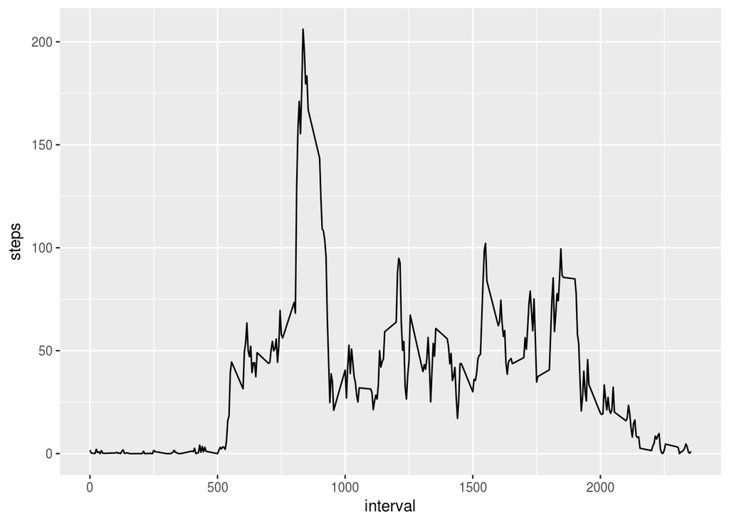

Maximum number of steps

```r
steps_per_interval <- aggregate(subdata$steps,
                                by = list(interval = as.factor(subdata$interval)),
                                FUN=mean, na.rm=TRUE)

steps_per_interval$interval <-
        as.integer(levels(steps_per_interval$interval)[steps_per_interval$interval])

colnames(steps_per_interval) <- c("interval", "steps")

ggplot(data=steps_per_interval, aes(x=interval, y=steps)) +
    geom_line()

#maximo intervalo
max_interval <- steps_per_interval[which.max(steps_per_interval$steps),]
max_interval
```

[output not shown]

## 6. Code to describe and show a strategy for imputing missing data

Note that there are a number of days/intervals where there are missing values (coded as NA). The presence of missing days may introduce bias into some calculations or summaries of the data.

Calculate and report the total number of missing values in the dataset (i.e. the total number of rows with NAs)

```r
vals.is.na <- sum(is.na(data$steps))
vals.is.na
```

[output not shown]

Devise a strategy for filling in all of the missing values in the dataset. The strategy does not need to be sophisticated. For example, you could use the mean/median for that day, or the mean for that 5-minute interval, etc.

```r
#average number of steps as a function of range
steps.iterval <- aggregate(steps ~ interval, data , FUN = mean)

head(data)

#change value NA
for (i in 1:nrow(data)){
     tmp <- data$steps[i]
     if(is.na(tmp)){
         for(j in 1:nrow(steps.iterval)){
             if(data$interval[i] == steps.iterval$interval[j]){
                 data$steps[i] = steps.iterval$steps[j]
                 break
             }
         }
     }
 }

head(data)
```

Create a new dataset that is equal to the original dataset but with the missing data filled in.

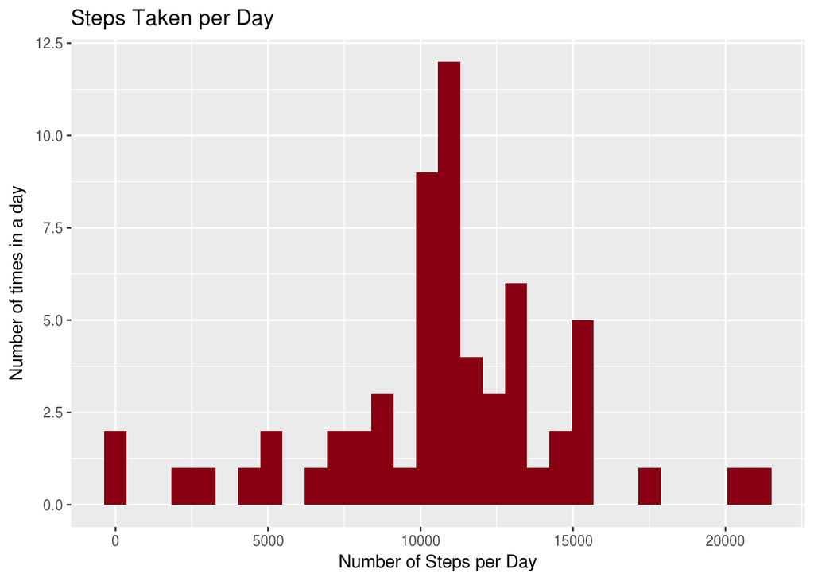

Steps Taken per Day

```r
#group for day
new.num.steps.date <- aggregate(data$steps, list(data$date), sum)
colnames(new.num.steps.date) <- c("date", "steps")

ggplot(data=new.num.steps.date, aes(x=steps)) +
  geom_histogram(fill="#880011") +
  ggtitle("Steps Taken per Day") +
  labs(x="Number of Steps per Day", y="Number of times in a day")
```

## 7. Histogram of the total number of steps taken each day after missing values are imputed

Make a histogram of the total number of steps taken each day and Calculate and report the mean and median total number of steps taken per day. Do these values differ from the estimates from the first part of the assignment? What is the impact of imputing missing data on the estimates of the total daily number of steps?

```r
#mean and median
new_steps_mean   <- mean(new.num.steps.date$steps)
new_steps_median <- median(new.num.steps.date$steps)
new_steps_mean
new_steps_median

new_steps_per_interval <- aggregate(data$steps,
                                by = list(interval = as.factor(data$interval)),
                                FUN=mean, na.rm=TRUE)

new_steps_per_interval$interval <-
        as.integer(levels(new_steps_per_interval$interval)[new_steps_per_interval$interval])

colnames(new_steps_per_interval) <- c("interval", "steps")

ggplot(data=new_steps_per_interval, aes(x=interval, y=steps)) +
    geom_line()
```

[output not shown]

```r
max_interval <- new_steps_per_interval[which.max(new_steps_per_interval$steps),]
max_interval
```

[output not shown]

[figure not shown]

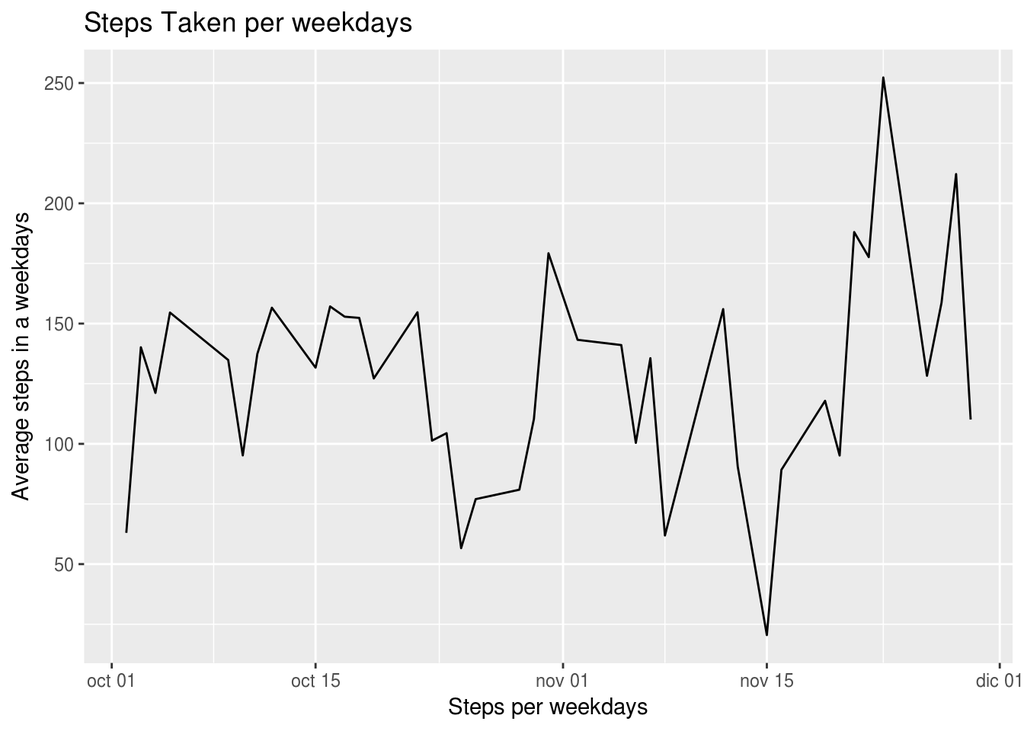

Average steps in a weekdays

```r
#The analysis has been done in Spanish so we filter for the weekend.
num.steps.date$d <- grepl("d.+",weekdays(num.steps.date$date))

#create data frame weekdays and weekends.
data.weekdays <- num.steps.date[num.steps.date$d==FALSE,]
data.weekends <- num.steps.date[num.steps.date$d==TRUE,]

ggplot(data=data.weekdays, aes(date,steps)) +
  geom_line() +
  ggtitle("Steps Taken per weekdays") +
  labs(x="Steps per weekdays", y="Average steps in a weekdays")
```

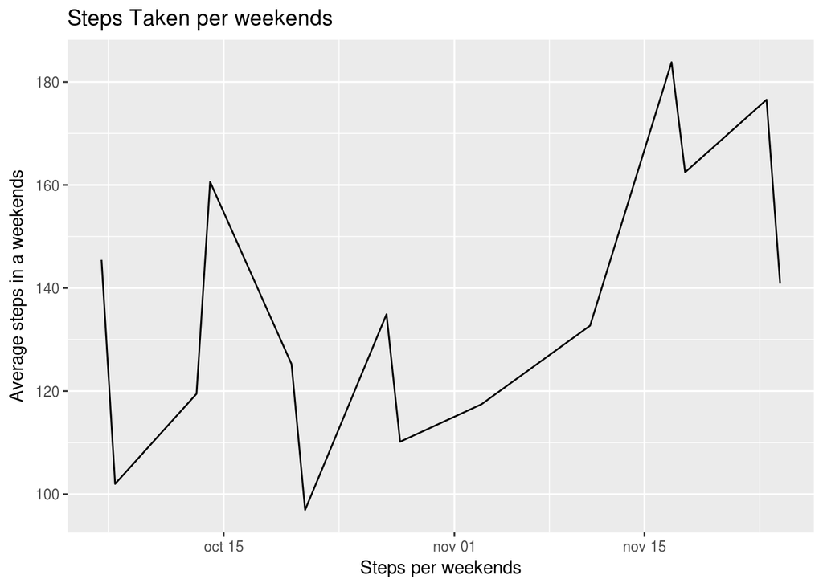

Average steps in a weekends

```r
ggplot(data=data.weekends, aes(date,steps)) +
  geom_line() +
  ggtitle("Steps Taken per weekends") +
  labs(x="Steps per weekends", y="Average steps in a weekends")
```